```python
import numpy as np
import pandas as pd
import seaborn as sns
import matplotlib.pyplot as plt
%matplotlib inline
from scipy.stats import norm
import statistics
import scipy.stats as stats
from scipy.stats import ttest_1samp, ttest_ind
from statsmodels.stats.power import ttest_power
```

```python
# Get the Data
wcd=pd.read_csv('Wholesale Customers Data.csv')
wcd.shape
```

```
(440, 8)
```

# Problem1

# 1.1 Use methods of descriptive statistics to summarize data. Which Region and which Channel spent the most? Which Region and which Channel spent the least?

```python
wcd.describe()
```

|  | Fresh | Milk | Grocery | Frozen | Detergents_Paper | Delicatessen |
| --- | --- | --- | --- | --- | --- | --- |
| count | 440.000000 | 440.000000 | 440.000000 | 440.000000 | 440.000000 | 440.000000 |
| mean | 12000.297727 | 5796.265909 | 7951.277273 | 3071.931818 | 2881.493182 | 1524.870455 |
| std | 12647.328865 | 7380.377175 | 9503.162829 | 4854.673333 | 4767.854448 | 2820.105937 |
| min | 3.000000 | 55.000000 | 3.000000 | 25.000000 | 3.000000 | 3.000000 |
| 25% | 3127.750000 | 1533.000000 | 2153.000000 | 742.250000 | 256.750000 | 408.250000 |
| 50% | 8504.000000 | 3627.000000 | 4755.500000 | 1526.000000 | 816.500000 | 965.500000 |
| 75% | 16933.750000 | 7190.250000 | 10655.750000 | 3554.250000 | 3922.000000 | 1820.250000 |
| max | 112151.000000 | 73498.000000 | 92780.000000 | 60869.000000 | 40827.000000 | 47943.000000 |

```python
a=(wcd['Fresh']+wcd['Milk']+wcd['Grocery']+wcd['Frozen']+wcd['Detergents_Paper']+wcd['Delicatessen']).groupby(wcd['Channel']).sum()
```

```python
a
# Hotel channel spent the most and Retail channel spent the least
```

```
Channel
Hotel     7999569
Retail    6619931
dtype: int64
```

```python
b=(wcd['Fresh']+wcd['Milk']+wcd['Grocery']+wcd['Frozen']+wcd['Detergents_Paper']+wcd['Delicatessen']).groupby(wcd['Region']).sum().sort_values(ascending=False)
```

```python
b
# Other Region spent the most and Oporto Region spent the least
```

```
Region
Other     10677599
Lisbon     2386813
Oporto     1555088
dtype: int64
```

# 1.2 There are 6 different varieties of items that are considered. Describe and comment/explain all the varieties across Region and Channel? Provide a detailed justification for your answer.

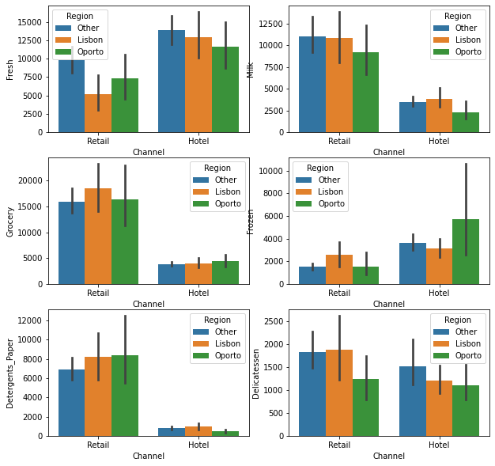

```python
plt.figure(figsize= (10,10))
plt.subplot(3,2,1)
sns.barplot(x=wcd['Channel'], y=wcd['Fresh'], hue=wcd['Region'])
plt.subplot(3,2,2)
sns.barplot(x=wcd['Channel'], y=wcd['Milk'], hue=wcd['Region'])
plt.subplot(3,2,3)
sns.barplot(x=wcd['Channel'], y=wcd['Grocery'], hue=wcd['Region'])
plt.subplot(3,2,4)
sns.barplot(x=wcd['Channel'], y=wcd['Frozen'], hue=wcd['Region'])
plt.subplot(3,2,5)
sns.barplot(x=wcd['Channel'], y=wcd['Detergents_Paper'], hue=wcd['Region'])
plt.subplot(3,2,6)
sns.barplot(x=wcd['Channel'], y=wcd['Delicatessen'], hue=wcd['Region'])
plt.show()
```

```python
Fresh=wcd['Fresh'].sum()
Milk=wcd['Milk'].sum()
Grocery=wcd['Grocery'].sum()
Frozen=wcd['Frozen'].sum()
Detergents_Paper=wcd['Detergents_Paper'].sum()
Delicatessen=wcd['Delicatessen'].sum()
a=(Fresh, Milk, Grocery, Frozen, Detergents_Paper, Delicatessen)
print(a)
```

```
(5280131, 2550357, 3498562, 1351650, 1267857, 670943)
```

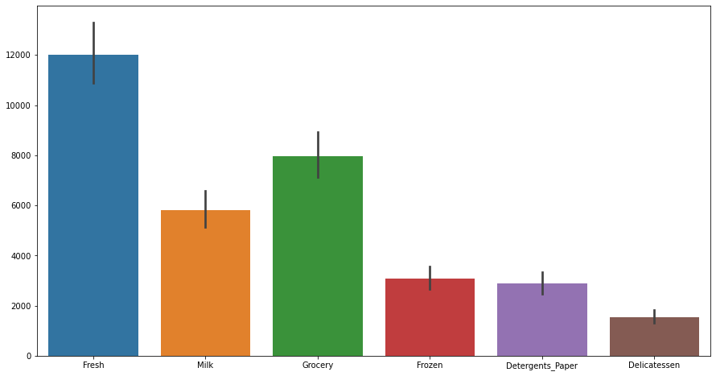

```python
plt.figure(figsize=(15,8))
sns.barplot(data=wcd)
```

```python
#In total, The customer spents more on Fresh products and least spent on Delicatessen
```

# 1.3 On the basis of a descriptive measure of variability, which item shows the most inconsistent behaviour? Which items show the least inconsistent behaviour?

```python
std=wcd.std()
std
```

```
Fresh               12647.328865
Milk                 7380.377175
Grocery              9503.162829
Frozen               4854.673333
Detergents_Paper     4767.854448
Delicatessen         2820.105937
dtype: float64
```

```python
#Fresh product have high Standard deviation. It is has most inconsistent behaviour.
#Delicatessen item have smallest Standard deviation. It is has least inconsistent behaviour
```

# 1.4 Are there any outliers in the data? Back up your answer with a suitable plot/technique with the help of detailed comments.

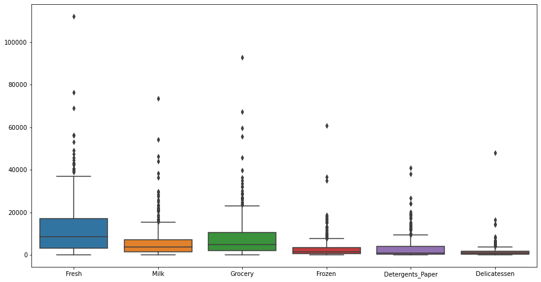

```python
plt.figure(figsize=(15,8))
sns.boxplot(data=wcd)
```

```python
#There is all products have outliers in the data. Those all are real data so no need to exclude any of data.
```

# Problem 2

# The Student News Service at Clear Mountain State University (CMSU) has decided to gather data about the undergraduate students that attend CMSU. CMSU creates and distributes a survey of 14 questions and receives responses from 62 undergraduates (stored in the Survey data set).

```python
# Get the Data
cmsu=pd.read_csv('Survey-1.csv')
cmsu.shape
```

```
(62, 14)
```

# 2.1. For this data, construct the following contingency tables (Keep Gender as row variable)

# 2.1.1. Gender and Major

```python
cmsu1=pd.crosstab(cmsu['Gender'], cmsu['Major'])
cmsu1
```

| Major Gender | Accounting | CIS | Economics/Finance | International Business | Management | Other | Retailing/Marketing | Undecided |
| --- | --- | --- | --- | --- | --- | --- | --- | --- |
| Female | 3 | 3 | 7 | 4 | 4 | 3 | 9 | 0 |
| Male | 4 | 1 | 4 | 2 | 6 | 4 | 5 | 3 |

# 2.1.2. Gender and Grad Intention

```python
cmsu2=pd.crosstab(cmsu['Gender'], cmsu['Grad Intention'])
cmsu2
```

| Grad Intention Gender | No | Undecided | Yes |
| --- | --- | --- | --- |
| Female | 9 | 13 | 11 |
| Male | 3 | 9 | 17 |

# 2.1.3. Gender and Employment

```python
cmsu3=pd.crosstab(cmsu['Gender'], cmsu['Employment'])
cmsu3
```

| Employment Gender | Full-Time | Part-Time | Unemployed |
| --- | --- | --- | --- |
| Female | 3 | 24 | 6 |
| Male | 7 | 19 | 3 |

# 2.1.4. Gender and Computer

```python
cmsu4=pd.crosstab(cmsu['Gender'], cmsu['Computer'])
cmsu4
```

| Computer Gender | Desktop | Laptop | Tablet |
| --- | --- | --- | --- |
| Female | 2 | 29 | 2 |
| Male | 3 | 26 | 0 |

# 2.2. Assume that the sample is representative of the population of CMSU. Based on the data, answer the following question:

```python
cmsu.info()
```

```
<class 'pandas.core.frame.DataFrame'>
RangeIndex: 62 entries, 0 to 61
Data columns (total 14 columns):
 #   Column             Non-Null Count  Dtype
---  ------             --------------  -----
 0   ID                 62 non-null     int64
 1   Gender             62 non-null     object
 2   Age                62 non-null     int64
 3   Class              62 non-null     object
 4   Major              62 non-null     object
 5   Grad Intention     62 non-null     object
 6   GPA                62 non-null     float64
 7   Employment         62 non-null     object
 8   Salary             62 non-null     float64
 9   Social Networking  62 non-null     int64
 10  Satisfaction       62 non-null     int64
 11  Spending           62 non-null     int64
 12  Computer           62 non-null     object
 13  Text Messages      62 non-null     int64
dtypes: float64(2), int64(6), object(6)
memory usage: 6.9+ KB
```

```python
cmsu['Gender'].value_counts()
```

```
Female    33
Male      29
Name: Gender, dtype: int64
```

# 2.2.1. What is the probability that a randomly selected CMSU student will be male?

```python
#Probability that a randomly selected CMSU student will be male=cmsu['Gender'=Male]/cmsu['Gender']
pm=(29/62)
pm
```

```
0.46774193548387094
```

# 2.2.2. What is the probability that a randomly selected CMSU student will be female?

```python
#Probability that a randomly selected CMSU student will be male=cmsu['Gender'=Female]/cmsu['Gender']
pf=33/62
pf
```

```
0.532258064516129
```

# 2.3. Assume that the sample is representative of the population of CMSU. Based on the data, answer the following question:

```python
cmsu5=pd.crosstab(cmsu['Gender'], cmsu['Major'])
cmsu5
```

| Major Gender | Accounting | CIS | Economics/Finance | International Business | Management | Other | Retailing/Marketing | Undecided |
| --- | --- | --- | --- | --- | --- | --- | --- | --- |
| Female | 3 | 3 | 7 | 4 | 4 | 3 | 9 | 0 |
| Male | 4 | 1 | 4 | 2 | 6 | 4 | 5 | 3 |

# 2.3.1. Find the conditional probability of different majors among the male students in CMSU.

```python
pfm=cmsu[cmsu['Gender']=='Male']
cmsu6=pd.crosstab(pfm['Gender'], cmsu['Major'])/29*100
cmsu6
```

| Major Gender | Accounting | CIS | Economics/Finance | International Business | Management | Other | Retailing/Marketing | Undecided |
| --- | --- | --- | --- | --- | --- | --- | --- | --- |
| Male | 13.793103 | 3.448276 | 13.793103 | 6.896552 | 20.689655 | 13.793103 | 17.241379 | 10.344828 |

Probability of males to take Accounting as major= 13.79% Probability of males to take CIS as major= 3.45% Probability of males to take Economics/Finance as major= 13.79% Probability of males to take International Business as major= 6.90% Probability of males to take Management as major= 20.69% Probability of males to take Other as major= 13.79% Probability of males to take Retailing/Marketing as major= 17.24% Probability of males to take Undecided as major= 10.34%

# 2.3.2 Find the conditional probability of different majors among the female students of CMSU.

```python
pff=cmsu[cmsu['Gender']=='Female']
cmsu7=pd.crosstab(pff['Gender'], cmsu['Major'])/33*100
cmsu7
```

| Major Gender | Accounting | CIS | Economics/Finance | International Business | Management | Other | Retailing/Marketing |
| --- | --- | --- | --- | --- | --- | --- | --- |
| Female | 9.090909 | 9.090909 | 21.212121 | 12.121212 | 12.121212 | 9.090909 | 27.272727 |

Probability of females to take Accounting as major= 9.09% Probability of females to take CIS as major= 9.09% Probability of females to take Economics/Finance as major= 21.21% Probability of females to take International Business as major= 12.12% Probability of females to take Management as major= 12.12% Probability of females to take Other as major= 9.09% Probability of females to take Retailing/Marketing as major= 27.27% Probability of females to take Undecided as major= 0%

# 2.4. Assume that the sample is a representative of the population of CMSU. Based on the data, answer the following question:

# 2.4.1. Find the probability That a randomly chosen student is a male and intends to graduate.

```python
pfm1=cmsu[cmsu['Gender']=='Male']
cmsu8=pd.crosstab(pfm1['Gender'], cmsu['Grad Intention'])
cmsu8
```

| Grad Intention Gender | No | Undecided | Yes |
| --- | --- | --- | --- |
| Male | 3 | 9 | 17 |

```python
pfmg=17/29*100
print("Probability That a randomly chosen student is a male and intends to graduate:", pfmg)
```

```
Probability That a randomly chosen student is a male and intends to graduate: 58.620689655172406
```

# 2.4.2 Find the probability that a randomly selected student is a female and does NOT have a laptop.

```python
cmsu9=pd.crosstab(cmsu['Gender'], cmsu['Computer'])
cmsu9
```

| Computer Gender | Desktop | Laptop | Tablet |
| --- | --- | --- | --- |
| Female | 2 | 29 | 2 |
| Male | 3 | 26 | 0 |

```python
pffnl=((33/62)+(7/62)-(4/62))*100
print("Probability that a randomly selected student is a female and does NOT have a laptop:", pffnl)
```

```
Probability that a randomly selected student is a female and does NOT have a laptop: 58.06451612903225
```

# 2.5. Assume that the sample is representative of the population of CMSU. Based on the data, answer the following question:

# 2.5.1. Find the probability that a randomly chosen student is a male or has full-time employment?

```python
cmsu['Gender'].value_counts()
```

```
Female    33
Male      29
Name: Gender, dtype: int64
```

```python
cmsu['Employment'].value_counts()
```

```
Part-Time     43
Full-Time     10
Unemployed     9
Name: Employment, dtype: int64
```

```python
pme=cmsu[cmsu['Gender']=='Male']
cmsu10=pd.crosstab(pme['Gender'], cmsu['Employment'])
cmsu10
```

| Employment Gender | Full-Time | Part-Time | Unemployed |
| --- | --- | --- | --- |
| Male | 7 | 19 | 3 |

```python
pm=29/62
pfe=10/62
pmfe=7/62
pt=(pm+pfe-pmfe)*100
pt
```

```
51.61290322580645
```

# 2.5.2. Find the conditional probability that given a female student is randomly chosen, she is majoring in international business or management.

```python
pfm=cmsu[cmsu['Gender']=='Female']
cmsu11=pd.crosstab(pfm['Gender'], cmsu['Major'])
cmsu11
```

| Major Gender | Accounting | CIS | Economics/Finance | International Business | Management | Other | Retailing/Marketing |
| --- | --- | --- | --- | --- | --- | --- | --- |
| Female | 3 | 3 | 7 | 4 | 4 | 3 | 9 |

```python
pfi=4/33
pfmm=4/33
pfm1=(pfi+pfmm)*100
pfm1
```

```
24.242424242424242
```

# 2.6. Construct a contingency table of Gender and Intent to Graduate at 2 levels (Yes/No). The Undecided students are not considered now and the table is a 2x2 table. Do you think the graduate intention and being female are independent events?

```python
pfg=cmsu[cmsu['Grad Intention']!='Undecided']
cmsu12=pd.crosstab(pfg['Gender'], cmsu['Grad Intention'], margins=True, margins_name="Total")
cmsu12
```

| Grad Intention Gender | No | Yes | Total |
| --- | --- | --- | --- |
| Female | 9 | 11 | 20 |
| Male | 3 | 17 | 20 |
| Total | 12 | 28 | 40 |

```python
pg=28/40
print("Probability of graduate intention:", pg)
```

```
Probability of graduate intention: 0.7
```

```python
pgf=11/20
print("Probability of graduate intention and being female:", pgf)
```

```
Probability of graduate intention and being female: 0.55
```

# 2.7. Note that there are four numerical (continuous) variables in the data set, GPA, Salary, Spending, and Text Messages.

```python
cmsu13=pd.crosstab(cmsu['Gender'], cmsu['GPA'], margins=True, margins_name="Total")
cmsu13
```

| GPA Gender | 2.3 | 2.4 | 2.5 | 2.6 | 2.8 | 2.9 | 3.0 | 3.1 | 3.2 | 3.3 | 3.4 | 3.5 | 3.6 | 3.7 | 3.8 | 3.9 | Total |
| --- | --- | --- | --- | --- | --- | --- | --- | --- | --- | --- | --- | --- | --- | --- | --- | --- | --- |
| Female | 1 | 1 | 2 | 0 | 1 | 3 | 5 | 2 | 4 | 3 | 2 | 4 | 1 | 2 | 1 | 1 | 33 |
| Male | 0 | 0 | 4 | 2 | 2 | 1 | 2 | 5 | 2 | 2 | 5 | 2 | 2 | 0 | 0 | 0 | 29 |
| Total | 1 | 1 | 6 | 2 | 3 | 4 | 7 | 7 | 6 | 5 | 7 | 6 | 3 | 2 | 1 | 1 | 62 |

# 2.7.1 If a student is chosen randomly, what is the probability that his/her GPA is less than 3?

```python
pgpa=17/62
print("Probability of GPA is less than 3:", pgpa)
```

```
Probability of GPA is less than 3: 0.27419354838709675
```

# 2.7.2. Find the conditional probability that a randomly selected male earns 50 or more. Find the conditional probability that a randomly selected female earns 50 or more.

```python
cmsu14=pd.crosstab(cmsu['Gender'], cmsu['Salary'], margins=True, margins_name="Total")
cmsu14
```

| Salary Gender | 25.0 | 30.0 | 35.0 | 37.0 | 37.5 | 40.0 | 42.0 | 45.0 | 47.0 | 47.5 | 50.0 | 52.0 | 54.0 | 55.0 | 60.0 | 65.0 | 70.0 | 78.0 | 80.0 | Total |
| --- | --- | --- | --- | --- | --- | --- | --- | --- | --- | --- | --- | --- | --- | --- | --- | --- | --- | --- | --- | --- |
| Female | 0 | 5 | 1 | 0 | 1 | 5 | 1 | 1 | 0 | 1 | 5 | 0 | 0 | 5 | 5 | 0 | 1 | 1 | 1 | 33 |
| Male | 1 | 0 | 1 | 1 | 0 | 7 | 0 | 4 | 1 | 0 | 4 | 1 | 1 | 3 | 3 | 1 | 0 | 0 | 1 | 29 |
| Total | 1 | 5 | 2 | 1 | 1 | 12 | 1 | 5 | 1 | 1 | 9 | 1 | 1 | 8 | 8 | 1 | 1 | 1 | 2 | 62 |

```python
pgs=cmsu[cmsu['Salary']>=50]
cmsu16=pd.crosstab(cmsu['Gender'], pgs['Salary'], margins=True, margins_name="Total")
cmsu16
```

| Salary Gender | 50.0 | 52.0 | 54.0 | 55.0 | 60.0 | 65.0 | 70.0 | 78.0 | 80.0 | Total |
| --- | --- | --- | --- | --- | --- | --- | --- | --- | --- | --- |
| Female | 5 | 0 | 0 | 5 | 5 | 0 | 1 | 1 | 1 | 18 |
| Male | 4 | 1 | 1 | 3 | 3 | 1 | 0 | 0 | 1 | 14 |
| Total | 9 | 1 | 1 | 8 | 8 | 1 | 1 | 1 | 2 | 32 |

```python
cmsu['Gender'].value_counts()
```

```
Female    33
Male      29
Name: Gender, dtype: int64
```

```python
pgsm=14/29
print("Probability of male earns 50 or more:", pgsm)
```

```
Probability of male earns 50 or more: 0.4827586206896552
```

```python
pgsf=18/33
print("Probability of female earns 50 or more:", pgsf)
```

```
Probability of female earns 50 or more: 0.5454545454545454
```